```python
# General Imports
import datetime
import pandas as pd
import numpy as np
import json
import time
import requests
import os

from matplotlib import pyplot as plt
from dateutil.relativedelta import relativedelta
```

# **INTRODUCTION - Investing for Anyone**

This is a tutorial on the basic process of designing a market trading algorithm and testing it. The specific topic that is used to demostrate the design and testing of a market trading algorithm is the question of whether or not the Dollar Cost Averaging strategy can be beaten by Buy the Bottom Strategy when applied to investing in the S&P 500. The intention is to find a simple algorithm for anyone to use without any financial knowledge required. As such, the analytical tools that will be incorporated will be sparse, but the overall method can still be applied generally.

Dollar Cost Averaging(DCA) takes the idea of a monthly budget and applies it to investing in the stock market. Every month, a set amount of money is used to purchase shares of stocks. This idea came to prominence when John Bogle pioneered index funds and passive investments.

The Buy the Bottom(BtB) strategy was inspired by an interview with Mark Cuban where he proposed that investors should just save money and buy when there's a crash. This is significantly less stressful but also requires financial expertise. But the real question is, does BtB produce greater returns than DCA?

From an investor perspective, it is very difficult to beat the market. It requires having an advantage on some of the biggest corporations with some of the hardest working people in the USA. As such, the average retail investor will typically be unable to beat the market, so investing in the S&P 500 is the best default option. When there does exist some advantage, it is encumbant upon the investor to act by moving funds from the S&P 500 to the alternative with a higher perceived value in the future. This is the best strategy for everyday people and is what great investors advise.

However, armed with this knowledge, is there some algorithm that is better than a simple buy a fixed amount every month?

**Useful Links:**

- John Bogle wiki: https://en.wikipedia.org/wiki/John_C._Bogle

## Motivation

The motivation behind this analysis is the desire to make more money in a simple way. Everyone wants more money and bigger numbers, as long as inflation is reasonable.

# **DATA COLLECTION, CURATION, & PARSING**

1. S&P 500
2. CPI-U
3. Business Cycles

#### Basic Architecture

Most data sources have some sort of bandwidth limit, so the initial data load will download all the data and save it to a file. Afterwards, the file will be updated as time passes.

### S & P 500

For S&P 500 data, Yahoo Finance was used as a source because it's free, open, and has daily OHLC(Open, High, Low, and Close) data. OHLC data is key for this analysis because we will be looking for market peaks and troughs using the Zig Zag indicator, which requires HLC data in order to be calculated. OHLC data is typically preferable to any single data point (i.e. Close) because it will reflect some of the tensions in the market. On a typical day on the stock market, the highest volume occurs during the end of the day followed by the start of the day. The High and Low will show the amount of price volatility in the day. Therefore, OHLC data is a good summary of what happened on the market that day and required for the Zig Zag indicator. There will be more discussion on the Zig Zag indicator later in the Exploratory Data Analysis.

The time period selected was Jan 1970 to now. The reason for this is because the stock market is generally managed via the Federal Funds Rate (FFR) in modern times. Using the FFR is nothing new, but Paul Volcker was the first to aggressively use it to fight inflation in the US during the 80s and establish the prescedent that the Fed manages the market via the FFR. Since then, the largest innovation or change to how the Fed manages the market is the use of Quantitative Easing(QE) created by Ben Bernanke after the 2009 mortgage crisis.

One possible motivation behind the creation of QE was the belief that taking the FFR to zero was not enough to stimulate the economy enough, and the fear that having a negative FFR would have severe and unpredictable effects, which is not good when the goal is to re-establish economic stability. However, using 2009 and the creation of QE as an analysis period would shrink an already small data set, which is stock market crash data. For this reason, January 1970 was a convenient limit to the Yahoo data set, although it is possible that the curators also had this in mind when specifiying the available dates.

**Note:**

A popular data set that is frequently used is the Robert Schiller data set. The problem with this data set is that it's monthly point data, and thus lacks much detail. Price volatility is important to analyzing markets and the lack of information on volatility is a severe weakness.

**Useful Links:**

- http://www.econ.yale.edu/~shiller/data.htm
- https://datahub.io/core/s-and-p-500/r/data.csv

```python
# Get Yahoo Data
def get_yahoo_sp500():

    def yahoo_time(in_time):
        return int(time.mktime(in_time.timetuple()))

    def downloader(ticker,start,end):
        interval = '1d' # 1d, 1m

        query_string = f'https://query1.finance.yahoo.com/v7/finance/download/{ticker}?' + \
                       f'period1={period1}&period2={period2}&interval={interval}' + \
                       f'&events=history&includeAdjustedClose=true'

        df = pd.read_csv(query_string)
        return df

    yahoo_file_name = "yahoo_sp500.csv"
    ticker = '^GSPC'

    if (not os.path.exists(yahoo_file_name)):
        # Download all data
        # Jan 1, 1970 corresponds to the zero value for the date time object used by Yahoo.
        period1 = yahoo_time(datetime.datetime(1970, 1, 1 , 23, 59))
        period2 = yahoo_time(datetime.datetime.now())

        raw_df = downloader(ticker,period1,period2)
        raw_df.to_csv(yahoo_file_name, index=False, header=True)
    else:
        # Update Data
        raw_df = pd.read_csv(yahoo_file_name)
        last_date = datetime.datetime.strptime(raw_df["Date"].max(),"%Y-%m-%d")

        if datetime.datetime.now() > last_date:
            period1 = yahoo_time(last_date + datetime.timedelta(days = 1))
            period2 = yahoo_time(datetime.datetime.now())

            try:
                new_df = downloader(ticker,period1,period2)
                raw_df = pd.concat([raw_df,new_df])
                raw_df.to_csv(yahoo_file_name, index=False, header=True)
            except:
                print("limit exceeded")

    # Final Quality of Life Improvements
    raw_df = raw_df.rename(columns = {"Adj Close":"Adj_Close"})
    raw_df["Date"] = pd.to_datetime(raw_df["Date"])

    return raw_df
```

### CPI-U

Inflation adjusting contributions is important because not doing so will give heavier weight to initial investments because \$100 in 1970 was worth much more than \\$100 in 2022. The Bureau of Labor Statistics provides this data and is the data source for this tutorial.

The BLS also has a daily and request data limit. The request data limit for CPI-U is 10 years.

**Useful Links:**

- https://www.bls.gov/cpi/
- https://www.bls.gov/developers/api_python.htm#python2

```python
# CPI - try to run once because there is a daily limit that's easily hit.
def CPIU_Getter( beg_year, end_year, force_download = False ):
    def bls_looper (start_year):
        headers = {'Content-type': 'application/json'}

        data = json.dumps({"seriesid": ["CUUR0000SA0"],
                           "startyear": str(start_year),
                           "endyear": str(start_year + 10)})

        p = requests.post('https://api.bls.gov/publicAPI/v2/timeseries/data/',
                          data=data, headers=headers)

        json_data = json.loads(p.text)['Results']['series'][0]["data"]
        tdf = pd.DataFrame(json_data)
        tdf["year"] = tdf["year"].astype(int)
        tdf["month"] = tdf["period"].apply(lambda x: int(x[1:]))

        return tdf

    cpi_file_name = "cpi_final_c3.csv"

    if (not os.path.exists(cpi_file_name) or force_download):

        # BLS only lets you download 10 years at a time
        acc = []
        for n in range(beg_year, end_year + 10, 10):

            if n <= datetime.datetime.now().year :
                tmp = bls_looper(n)
                acc.append(tmp)

        full = pd.concat(acc)
        full = full.drop(["periodName","period","footnotes"], axis = 1).sort_values(["year","month"])
        full.to_csv(cpi_file_name, index = False)
        dl_df = full

    else:
        dl_df = pd.read_csv(cpi_file_name)

    return dl_df
```

### Business Cycle Data

The economic business cycle is a good indicator/substitute for identifiying peaks and troughs. Though the stock market is a little more prospective than economic indicators, business cycle dates will help identify peaks and troughs to help with the BtB strategy.The National Bureau of Economic Research (NBER) maintains this data.

**Useful Links:**

- https://fredhelp.stlouisfed.org/fred/data/understanding-the-data/recession-bars/

```python
# small dataset with no bandwidth limit
def get_business_cycles(raw = False):

    start_date = "1969-7-1" # limited for Yahoo S&P data

    url = "http://data.nber.org/data/cycles/20210719_cycle_dates_pasted.csv"
    df = pd.read_csv(url)

    df["peak"] = pd.to_datetime(df["peak"])
    df["trough"] = pd.to_datetime(df["trough"])

    # limit data to relevant range
    df = df[df["peak"] > start_date]

    # transform data to match pivots format from Zig Zag algorithm
    if not raw :
        dfp = df[["peak"]].copy()
        dfp["Pivots"] = 1
        dfp["Date"] = dfp["peak"]

        dft = df[["trough"]].copy()
        dft["Pivots"] = -1
        dft["Date"] = dft["trough"]
        df = pd.concat([dfp, dft]).sort_values("Date").drop(["peak","trough"], axis = 1)

    return df
```

# **DATA MANAGEMENT & REPRESENTATION**

1. Zig Zag Indicator

### Zig Zag Indicator - TAKEN FROM THE INTERNET

The Zig Zag Indicator is a technical analysis tool that identifies peaks and troughs based on a percent change threshold. To remove the noise in the stock market, the Zig Zag indicator was used to filter out minor movements, so that we can analyze the major moves, which should correlate with the business cycle data from the NBER.

For the BtB strategy, the troughs will serve as a trigger to purchase stocks.

The Zig Zag algorithm is complex. An implementation was found from Stack Overflow and integrated into this workbook.

**Useful Links:**

- https://stackoverflow.com/questions/65800877/python-zig-zag-algorithm-function-not-returning-expected-results

```python
# From the Internet
PEAK, VALLEY = 1, -1

def _identify_initial_pivot(X, up_thresh, down_thresh):
# Quickly identify the X[0] as a peak or valley
    x_0 = X[0]
    max_x = x_0
    max_t = 0
    min_x = x_0
    min_t = 0
    up_thresh += 1
    down_thresh += 1

    for t in range(1, len(X)):
        x_t = X[t]

        if x_t / min_x >= up_thresh:
            return VALLEY if min_t == 0 else PEAK

        if x_t / max_x <= down_thresh:
            return PEAK if max_t == 0 else VALLEY

        if x_t > max_x:
            max_x = x_t
            max_t = t

        if x_t < min_x:
            min_x = x_t
            min_t = t

    t_n = len(X)-1

    return VALLEY if x_0 < X[t_n] else PEAK
```

```python
# From the Internet
def peak_valley_pivots_candlestick(close, high, low, up_thresh, down_thresh):
    """
    Finds the peaks and valleys of a series of HLC (open is not necessary).
    TR: This is modified peak_valley_pivots function in order to find peaks and valleys for OHLC.
    Parameters
    ----------
    close : This is series with closes prices.
    high : This is series with highs  prices.
    low : This is series with lows prices.
    up_thresh : The minimum relative change necessary to define a peak.
    down_thesh : The minimum relative change necessary to define a valley.
    Returns
    -------
    an array with 0 indicating no pivot and -1 and 1 indicating valley and peak
    respectively
    Using Pandas
    ------------
    For the most part, close, high and low may be a pandas series. However, the index must
    either be [0,n) or a DateTimeIndex. Why? This function does X[t] to access
    each element where t is in [0,n).
    The First and Last Elements
    ---------------------------
    The first and last elements are guaranteed to be annotated as peak or
    valley even if the segments formed do not have the necessary relative
    changes. This is a tradeoff between technical correctness and the
    propensity to make mistakes in data analysis. The possible mistake is
    ignoring data outside the fully realized segments, which may bias analysis.
    """
    if down_thresh > 0:
        raise ValueError('The down_thresh must be negative.')

    initial_pivot = _identify_initial_pivot(close, up_thresh, down_thresh)

    t_n = len(close)
    pivots = np.zeros(t_n, dtype='i1')
    pivots[0] = initial_pivot

    # Adding one to the relative change thresholds saves operations. Instead
    # of computing relative change at each point as x_j / x_i - 1, it is
    # computed as x_j / x_1. Then, this value is compared to the threshold + 1.
    # This saves (t_n - 1) subtractions.
    up_thresh += 1
    down_thresh += 1

    trend = -initial_pivot
    last_pivot_t = 0
    last_pivot_x = close[0]
    for t in range(1, len(close)):

        if trend == -1:
            x = low[t]
            r = x / last_pivot_x
            if r >= up_thresh:
                pivots[last_pivot_t] = trend#
                trend = 1
                #last_pivot_x = x
                last_pivot_x = high[t]
                last_pivot_t = t
            elif x < last_pivot_x:
                last_pivot_x = x
                last_pivot_t = t
        else:
            x = high[t]
            r = x / last_pivot_x
            if r <= down_thresh:
                pivots[last_pivot_t] = trend
                trend = -1
                #last_pivot_x = x
                last_pivot_x = low[t]
                last_pivot_t = t
            elif x > last_pivot_x:
                last_pivot_x = x
                last_pivot_t = t


    if last_pivot_t == t_n-1:
        pivots[last_pivot_t] = trend
    elif pivots[t_n-1] == 0:
        pivots[t_n-1] = trend

    return pivots
```

```python
# Created by Leo to get pivot data
def get_zig_zag_pivots(df, threshold_pct):

    def thingy(reau):
        if reau["Pivots"] == 1:
            return reau["High"]
        elif reau["Pivots"] == -1:
            return reau["Low"]
        else:
            return np.NAN

    print("Calculating Pivots for ", threshold_pct * 100, "%")
    # data parse
    df_out = df.copy()
    down_threshold = -threshold_pct

    pivots = peak_valley_pivots_candlestick(df.Close.values, df.High.values, df.Low.values ,threshold_pct,down_threshold)

    df_out['Pivots'] = pivots
    df_out['Pivot_Price'] = np.nan  # This line clears old pivot prices

    df_out['Pivot_Price'] = df_out.apply(thingy, axis = 1)

    return df_out
```

# **Exploratory Data Analysis**

1. Finding the percent threshold for the Zig Zag indicator to match the Business Cycle
2. Visualizing the peaks and troughs
3. Analyzing the peaks and troughs vs time

### Finding the Percent Threshold where Zig Zag Identifies the Business Cycle

To find the best threshold, we will first try to find the number of business cycles in the data and then try to get the corresponding number of Zig Zag pivot indicators. This will hopefully result in pivot points near the peak and trough of each stock market cycle.

Based on the plot below, 25% seems to be the point where the number of business cycle dates matches the number of Zig Zag pivots.

```python
# get data
raw_sp = get_yahoo_sp500()
busi_cycle = get_business_cycles()

# Get Pivots for various thresholds using ZigZag indicator/algorithm
int_threshold =[]
pivot_count = []

# Calculate pivots based on thresholds
for i in range(20, 30):
    raw_zz = get_zig_zag_pivots(raw_sp, i/100)  # 0.27 is the sweet spot
    pivots = raw_zz[raw_zz["Pivots"] != 0]

    int_threshold.append(i)

    pivot_count.append(len(pivots.index))
```

```
limit exceeded
Calculating Pivots for  20.0 %
Calculating Pivots for  21.0 %
Calculating Pivots for  22.0 %
Calculating Pivots for  23.0 %
Calculating Pivots for  24.0 %
Calculating Pivots for  25.0 %
Calculating Pivots for  26.0 %
Calculating Pivots for  27.0 %
Calculating Pivots for  28.000000000000004 %
Calculating Pivots for  28.999999999999996 %
```

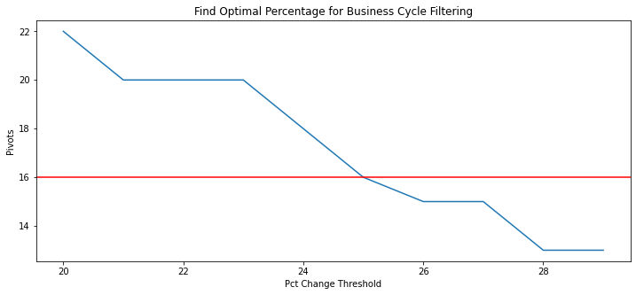

```python
# plot threshold vs pivots
fig, ax = plt.subplots(figsize=(12,5))

# plot raw data
ax.plot(int_threshold, pivot_count)
ax.set_xlabel("Pct Change Threshold")
ax.set_ylabel("Pivots")
ax.set_title("Find Optimal Percentage for Business Cycle Filtering")


# fit an exponential decay curve
x_val = int_threshold
y_val = pivot_count

ax.axhline(y=len(busi_cycle), color='r', linestyle='-')

fig.savefig("optimal_pct_threshold.png")
```

### Visualizing The Peaks and Troughs

By ploting the pivots from the Zig Zag indicator, we can see if the pivot points match up well with major declines in the stock market and the corresponding troughs.

#### Initial Review

```
Calculating Pivots for  25.0 %
```

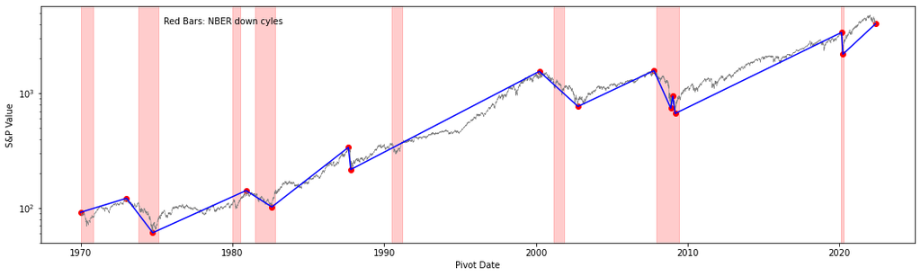

```python
df = get_zig_zag_pivots(raw_sp, 25/100)
#localz = get_pivot_changes(optimal_pivots)
fig, ax = plt.subplots(figsize=(18,5))

# add S&P Values
ax.plot(pd.to_datetime(df["Date"]), df.Close.values, color='grey', linewidth=0.5)
ax.scatter(df["Date"], df["Pivot_Price"], color = "red")

# add S&P500 Pivots
pivots = df.dropna(subset=["Pivot_Price"])
ax.plot(pd.to_datetime(pivots["Date"]), pivots["Pivot_Price"], color='blue')

# add business cycle bars
rbc = get_business_cycles(True)
def bull_cycle(date1):
    for cycle in rbc.values:
        if cycle[0] <= date1 <= cycle[1]:
            return True
        return False

for cycle in rbc.values:
    ax.fill_between(df["Date"], 0, 1,
                    where = df["Date"].apply(lambda x : cycle[0] <= x <= cycle[1]),
                    color='red', alpha=0.2, transform=ax.get_xaxis_transform())

# final graph formating
border = 0.2
y_rng = [(1 - border) * df.Close.values.min() , df.Close.values.max()*(1 + border) ]
ax.set_ylim(y_rng)
ax.set_xlabel("Pivot Date")
ax.set_ylabel("S&P Value")
ax.set_yscale('log')

ax.text(1990, 4000,"Red Bars: NBER down cyles")

fig.savefig("log_snp.png")
```

#### Manual Update

Based on the initial data plot, we can see that the 25% threshold performs well on finding major market moves, but doesn't line up with the business cycle data very well. Not lining up with the business cycle is not a problem as the business cycles were meant to be a heuristic for market peaks and troughs.

```
Calculating Pivots for  27.0 %
```

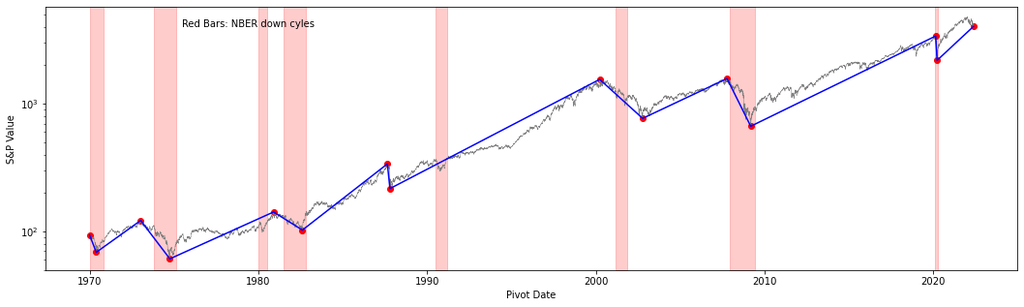

```python
df = get_zig_zag_pivots(raw_sp, 27/100)
#localz = get_pivot_changes(optimal_pivots)
fig, ax = plt.subplots(figsize=(18,5))

# add S&P Values
ax.plot(pd.to_datetime(df["Date"]), df.Close.values, color='grey', linewidth=0.5)
ax.scatter(df["Date"], df["Pivot_Price"], color = "red")

# add S&P500 Pivots
pivots = df.dropna(subset=["Pivot_Price"])
ax.plot(pd.to_datetime(pivots["Date"]), pivots["Pivot_Price"], color='blue')

# add business cycle bars
rbc = get_business_cycles(True)
def bull_cycle(date1):
    for cycle in rbc.values:
        if cycle[0] <= date1 <= cycle[1]:
            return True
        return False

for cycle in rbc.values:
    ax.fill_between(df["Date"], 0, 1,
                    where = df["Date"].apply(lambda x : cycle[0] <= x <= cycle[1]),
                    color='red', alpha=0.2, transform=ax.get_xaxis_transform())

# final graph formating
border = 0.2
y_rng = [(1 - border) * df.Close.values.min() , df.Close.values.max()*(1 + border) ]
ax.set_ylim(y_rng)
ax.set_xlabel("Pivot Date")
ax.set_ylabel("S&P Value")
ax.set_yscale('log')
ax.text(1990, 4000,"Red Bars: NBER down cyles")

fig.savefig("log_snp.png")
```

#### Reviewing the Results

The result at 27% is significantly better because we lose the 2009 double dip and we get the extra dip in 1970 business cycle dip. Now the only anomalies are the 1980 and the 1991 business cycle dips, and the 1987 crash that wasn't business cycle related.

Although these are differences, the differences are not relevant to our analysis because we want to identify stock market peaks and troughs using the business cycle as a proxy. For this, the business cycle has served its purpose.

### Analyzing Returns vs Time

To gain more understanding of the market, we'll analyze returns vs time and see if there's consistent behavior that can be used for the BtB strategy. For this specific implementation of BtB, I'm going to use a set drop threshold where purchasing gets triggered and a time span for periodic buying.

For the drop threshold, I'll use the 27% we found in the above Zig Zag indicator search. The following analysis will be for finding the time span for periodic buying. In this implementation, the period will be a month.

```python
# Calculate Returns
def get_pivot_changes(df):

    df_out = df.copy()

    df_out["pct_d_val"] = df_out["Pivot_Price"].pct_change()
    df_out["d_time"] = df_out["Date"].diff()

    df_out["d_time"]  = df_out["d_time"].apply(lambda x: x.days)

    return df_out

optimal_zz_threshold = 0.27

raw_zz = get_zig_zag_pivots(raw_sp, optimal_zz_threshold)
optimal_pivots = raw_zz[raw_zz["Pivots"] != 0]
det_opt_piv = get_pivot_changes(optimal_pivots)
```

```
Calculating Pivots for  27.0 %
```

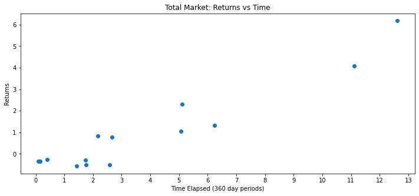

```python
fig, ax = plt.subplots(figsize=(12,5))


max_time = det_opt_piv["d_time"].max()
x_labels = [x for x in range(0, int(max_time) + 180, 360)]
ax.scatter(det_opt_piv["d_time"],det_opt_piv["pct_d_val"])
ax.set_xlabel("Time Elapsed (360 day periods)")
ax.set_ylabel("Returns")
ax.set_title("Total Market: Returns vs Time")

ax.set_xticks(x_labels)
ax.set_xticklabels([x for x in range(0,14)])
fig.savefig("simple_scatter.png")
```

```python
avg_days_bull = det_opt_piv[det_opt_piv["pct_d_val"] > 0]["d_time"].median()
print("Bull Market Life: ",avg_days_bull, "days, ", avg_days_bull/360, " years" )

avg_days_bear = det_opt_piv[det_opt_piv["pct_d_val"] < 0]["d_time"].median()
print("Bear Market Life: ",avg_days_bear, "days, ", avg_days_bear/360, " years" )
```

```
Bull Market Life:  1839.0 days,  5.108333333333333  years
Bear Market Life:  512.0 days,  1.4222222222222223  years
```

#### Reviewing the Plot

What we see here is a few of the quirks of stock market data. There seems to be some sort of log normal distribution of the pivot points. This makes sense because returns can not occur over negative time, the most you can lose is 100%, and there's no limit to how long a bull market runs or the returns of the bull market.

There appears to be 4 overall clusters, but if that is further split between bear and bull markets, then we see 3 clusters of bull markets and 3 clusters of bear markets. Unfortunately, as with most analysis of major events, there's no statistically representative sample and even between events, the world changes so much that it might not be relevant to compare across time periods.

Overall, it looks like the median bear markest last for about 1.4 years and the median bull markets last for about 5.1 years.

# **Hypothesis Testing**

- Null Hypothesis: returns from BtB are not significantly different from DCA returns
- Alternative Hypothesis: returns from BtB is significantly different from DCA returns

To test this we will need to create a back testing system. The back testing system will take buy/sell rules and calculate the returns. A typical back testing algorithm will typically find buy/sell triggers and apply those triggers to a particular stock without regard to funding because funding is managed by another risk management algorithm.

For the purpose of modeling the investments of an individual, we will build a back testing system that will also have a funding calculation mechanism. For the purposes of this analysis, the funding algorithm will be a fixed value with CPI adjustment. Without a CPI adjustment, there will be a natural favor toward DCA because the earliest possible investment is typically the best. Earlier investments are better because there's more time for the investment to accrue and the stock market has always had higher highs and higher lows.

#### Building the Backtester - Overview

The structure of the back tester is inspired by the Strategy design pattern. For more info, see the links below.

**Useful Links:**

- https://en.wikipedia.org/wiki/Strategy_pattern
- https://en.wikipedia.org/wiki/Design_Patterns

```python
def backtester(price_df, fn_funding, fn_purchases):

    df = price_df.copy()
    df = fn_funding(df)
    df = fn_purchases(df)

    return df
```

#### Building the Backtester - **Funding Function**

A closure was used so that the funding algorithm could be easily updated by injecting different settings.

```python
def dca_funding(days_between_purchases = 30, init_day_offset = 0, base_amount = 100, cpi = None):
    def closure(df):

        # get date range
        start = df["Date"].min() + datetime.timedelta(days = init_day_offset)
        end = df["Date"].max()

        out_list = []
        date = start

        # create days between start and end in even periods
        while date < end:
            out_list.append(date)
            date = date + datetime.timedelta(days = days_between_purchases)

        datez = pd.DataFrame(data= {"Date1":out_list})
        tmp_df = pd.DataFrame({"Date1":df["Date"].copy(), "Date": df["Date"].copy()})
        df1 = pd.merge_asof(datez, tmp_df, on="Date1", direction = "nearest")
        df1 = df1.drop(["Date1"],axis = 1)

        # add columns for quality of life improvement for analysis
        df1["year"] = df1["Date"].apply(lambda x : x.year)
        df1["month"] = df1["Date"].apply(lambda x : x.month)

        # allows for adjustment due to CPI
        # can be used to create functional funding strategies
        if cpi is None:
            df3["funding"] = base_amount

        else:
            base_index = cpi[(cpi["year"] == start.year) & (cpi["month"] == start.month)]["value"].values[0]

            adj_cpi = cpi.copy()
            adj_cpi["adj_index"] = adj_cpi["value"].apply(lambda x: float(x)/base_index)

            df3 = df1.merge(adj_cpi, left_on=["year","month"],right_on=["year","month"] ,how='left')

            df3["real_funding"] = base_amount
            df3["funding"] = df3["adj_index"] * df3["real_funding"]

            df3["funding"] = df3["funding"].apply(lambda x: round(x,2))
            df3 = df3.drop(["real_funding", "adj_index", "year","month", "value"], axis = 1)

        # final clean up
        df = df.merge(df3, left_on="Date", right_on="Date", how="left")

        df["funding"] = df["funding"].fillna(0)
        df["total_invested"] = df["funding"].cumsum()

        return df


    return closure
```

## Strategy - Basic Architecture

For the purpose of creating the most flexible strategy function possible, an initial function where the user may inject any data they want with a returned closure that uses the injected data was ideal. Although DCA did not need this, the other strategy functions benefited from the modularity of injection data.

As stated before, this follows the strategy design pattern. The interface that we're using is "function_name(data_frame) -> data_frame".

## Strategy - **Dollar Cost Average Strategy**

#### Purchasing Function

```python
def dca_strategy(df):
    # calculate purchases (changes within a period)
    df["purchase_price"] = (df["High"] + df["Low"] + 2 * df["Close"])/4
    df["purchased_shares"] = df["funding"]/df["purchase_price"]
    df["purchased_shares"] = df["purchased_shares"].apply(lambda x: 0 if (x == float("inf")) else x)

    # calculate balances (aggregation of changes)
    df["total_shares"] = df["purchased_shares"].cumsum()
    df["total_value"] = df["total_shares"] * df["Close"]
    df["total_value"] = df["total_value"].apply(lambda x: round(x,2))

    df["pct_return"] = ((df["total_value"]/df["total_invested"]) - 1) * 100

    return df
```

#### Base Result Calculation

```python
# prepare the input data
dca_df = raw_sp.copy()
cpi_df = CPIU_Getter(1970, 2022)
funding = dca_funding(cpi = cpi_df)

# run the back tester
dca_df = backtester(dca_df, funding, dca_strategy)
dca_df = dca_df.dropna(subset = ["purchased_shares"])
dca_df = dca_df[dca_df["purchased_shares"] != 0 ]

# print results
dca_df.iloc[-1]
```

```
Date                2022-04-29 00:00:00
Open                            4253.75
High                        4269.680176
Low                         4124.279785
Close                       4131.930176
Adj_Close                   4131.930176
Volume                       3943480000
latest                             True
funding                          764.84
total_invested                258073.66
purchase_price              4164.455078
purchased_shares               0.183659
total_shares                 552.254697
total_value                  2281877.85
pct_return                   784.196338
Name: 13199, dtype: object
```

#### Population of All Monthly DCA Returns

```python
# run the DCA model with different start dates
dca_models=[]
dca_df = raw_sp.copy()
for i in range(0,30):
    funding = dca_funding(init_day_offset = i, cpi = cpi_df)

    tmp = backtester(dca_df, funding, dca_strategy)
    tmp = tmp.sort_values(["Date"]).iloc[-1]
    #print(tmp["Date"])
    dca_models.append(tmp)
```

```python
# find the summary statistics
dca_shares = []
for i in range(0,30):
    dca_shares.append(dca_models[i]["pct_return"])

avg_return = np.mean(dca_shares)
std_return = np.std(dca_shares)
```

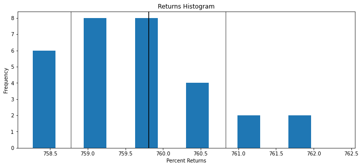

```python
# plot summary statistics
fig, ax = plt.subplots(figsize=(12,5))
ax.hist(dca_shares, bins='auto', width = 0.3)
ax.axvline(avg_return, color="black")
ax.axvline(avg_return + std_return, color="grey")
ax.axvline(avg_return - std_return, color="grey")
ax.set_xlabel("Percent Returns")
ax.set_ylabel("Frequency")
ax.set_title("Returns Histogram")

_ = fig
```

#### Population of All Monthly DCA Returns - Review

There looks to be something systematic that's causing a sawtooth pattern. Unfortunately, due to time constraints, I can't look into this, and have to take the average and standard deviation of returns as is.

However, the most insightful part of this is the low variability of returns in this method of building a population. I would expect variability to decrease with more funding points, but that investigation is not the purpose of this analysis. There were other dimensions that could have been varied, such as the frequency of the funding algorithm, but buying on any specific day does not produce significant differences in returns (4% - 5%).

Seeing as how $\beta$ is the most common measure of price volatility, it makes sense that other metrics would not be very useful, especially one like the metric used above. I chose against using $\beta$ because I did not want this to use more sophisticated measures. This tutorial's purpose is to find a simple strategy that takes little expertise or thinking because DCA should be the default strategy upon which your portfolio is built.

**Useful Links:**

- https://en.wikipedia.org/wiki/Beta_(finance)

## Strategy - **Buy the Bottom Strategy**

For this strategy, I'm going to initially give the strategy an advantage by having it buy at the lowest price during the business cycle. If there's a significant advantage, then further investigation will be warranted. Knowing the peaks and troughs is a significant advantage that can't be used in a real strategy because no one knows exactly when tops and bottoms will happen. However, this simplifies the programming so we can check to see if there's some value worth further investigation.

```python
def pure_bottom_purchase_strategy(df, threshold):

    pivots = get_zig_zag_pivots(df, threshold).dropna()

    def closure (df):

        # get the troughs
        trough_datez = pivots[pivots["Pivots"] == -1]["Date"].values
        df["purchase_price"] = (df["High"] + df["Low"] + 2 * df["Close"])/4

        # calculate purchases with troughs as the trigger to move
        # all savings into stocks
        savings_balance = 0
        for i, r in df.iterrows():
            savings_balance = savings_balance + r["funding"]
            if r["Date"] in trough_datez:
                df.loc[i,"purchased_shares"] = savings_balance/r["purchase_price"]
                savings_balance = 0

            df.loc[i,"savings_balance"] = savings_balance

        # calculation of balances
        df["total_shares"] = df["purchased_shares"].cumsum()
        df["total_shares"] = df["total_shares"].fillna(method="ffill")
        df["total_value"] = df["total_shares"] * df["Close"] +  df["savings_balance"]
        df["total_value"] = df["total_value"].apply(lambda x: round(x,2))
        df["pct_return"] = ((df["total_value"]/df["total_invested"]) - 1) * 100

        return df

    return closure
```

```python
# prep data for injection
bottom_only_df = raw_sp.copy()
funding = dca_funding(cpi = cpi_df)
bottom_strategy = pure_bottom_purchase_strategy(bottom_only_df, 0.27)

# run the back tester
tmp = backtester(dca_df, funding, bottom_strategy)

# run code to keep the last row to review returns
tmp.iloc[-1,tmp.columns.get_loc("purchased_shares")] = 1 # keep last row to get current return
btb_df = tmp.dropna(subset = ["purchased_shares"])
btb_df = btb_df[btb_df["purchased_shares"] != 0 ]
btb_df.iloc[-1,tmp.columns.get_loc("purchased_shares")] = 0

# print results
btb_df.iloc[-1]
```

```
Calculating Pivots for  27.0 %
```

```
Date                2022-05-16 00:00:00
Open                         4013.02002
High                        4027.360107
Low                          3983.98999
Close                       4018.429932
Adj_Close                   4018.429932
Volume                       1121509000
latest                              NaN
funding                             0.0
total_invested                258073.66
purchase_price               4012.05249
savings_balance                18523.88
purchased_shares                    0.0
total_shares                 541.991867
total_value                  2196480.22
pct_return                   751.105928
Name: 13210, dtype: object
```

```python
# calculate the p-value of the returns
btb_return = btb_df.iloc[-1]["pct_return"]
btb_return_pval = (btb_return - avg_return)/std_return

print("Buy the Bottom p-value:",btb_return_pval)
```

```
Buy the Bottom p-value: -8.478804258861071
```

#### Buy the Bottom Strategy - Review

Buy the Bottom is significantly different from Dollar Cost Averaging. However, the difference is a significant disadvantage. So even if you knew exactly when to buy at the bottom, you won't be able to beat DCA in the past 50 years. This is likely due to all the opportunities to buy at a price lower than the next trough being missed with the BtB strategy.

The major strength of buying the bottom is the lack of stress associated with holding during the falling phase of the market. However, this comes at the expense of missing out on all the value that could have been generated by shares purchased at a price lower than the next trough.

Another major issue is the fact that you can't possibly expect anyone to know the lowest point of the trough without hindsight. With the knowledge of the average length of a bear and bull market, and knowledge of what percentage drop constitutes a "crash", is it possible to combine these to create a more realistic algorithm that doesn't require hindsight?

## Strategy - **Check Mark Strategy**

The idea behind the Check Mark strategy is at some drop threshold, we will start buying using the savings that have been accrued since we stopped buying once a bull market is past the average bull market.

This will be more realistic than BtB because the strategy does not require the hindsight of knowing the troughs and allow for the continued purchase of shares for sometime after a trough.

```python
def check_mark_purchase_plan(df, pivots, purchase_threshold, savings_periods, dca_periods, period_length):
    pivots["trigger_price"] = pivots["Pivot_Price"] * (1 - purchase_threshold)
    pivots["Date_+1"] = pivots["Date"].shift(periods=-1)


    df["purchase_price"] = (df["High"] + df["Low"] + 2 * df["Close"])/4
    purchase_plans = []

    prior_purchase_start_date = np.datetime64('1941-12-07')
    for i,r in pivots.iterrows():
        # prevents overlapping plans
        bear_start_date = r["Date"]
        bear_end_date = r["Date_+1"]

        tmp_df = df[(df['Date'] >= bear_start_date) & (df['Date'] <= bear_end_date)]
        tmp_df = tmp_df[tmp_df["purchase_price"] < r["trigger_price"]].sort_values("Date")

        if len(tmp_df.index) > 0:
            prior_purchase_end_date = prior_purchase_start_date + \
                np.timedelta64(int(savings_periods + dca_periods)*period_length, 'D')

            if prior_purchase_end_date > tmp_df["Date"].values[0]:
                continue

            purchase_start_date = tmp_df["Date"].values[0]
            prior_purchase_start_date = purchase_start_date
            i = 0

            one_p_plan = []
            date = purchase_start_date

            # generate purchase plan
            while i < (savings_periods + dca_periods):
                i = i + 1
                one_p_plan.append(date)
                date = date + np.timedelta64(period_length, 'D')

            datez_df = pd.DataFrame({"purchase_plan_date":one_p_plan})
            datez_df["purchase_phase"] = datez_df.index.map(
                lambda x: "savings" if x < savings_periods else "dca")
            purchase_plans.append(datez_df)

    return purchase_plans

def check_mark_strategy(drop_threshold, purchase_threshold,
                        savings_periods, dca_periods, period_length = 30):

    pivots = get_zig_zag_pivots(df, drop_threshold).dropna()


    def closure (df):
        # create purchase plans
        purchase_plans = check_mark_purchase_plan(df,pivots,purchase_threshold,savings_periods, dca_periods, period_length)
        final_plan = pd.concat(purchase_plans).sort_values("purchase_plan_date")
        df_planz = pd.merge_asof(right=df["Date"], left=final_plan, right_on="Date", left_on = "purchase_plan_date",direction='nearest')

        # prevent purchase after last date
        df_planz= df_planz[df_planz["purchase_plan_date"] < df["Date"].iloc[-1]]

        # apply the plans
        df = df.merge(df_planz, how="left", on= "Date")

        savings_counter = 0
        savings_balance = 0
        for i,r in df.iterrows():
            savings_balance = savings_balance + r["funding"]

            if not pd.isna(r["purchase_phase"]):
                # use savings
                if r["purchase_phase"] == "savings":
                    if savings_counter == 0 :
                        savings_counter = savings_periods

                    purchase_amount = savings_balance / savings_counter
                    shares_purchased = purchase_amount/r["purchase_price"]
                    df.loc[i,"purchased_shares"] = shares_purchased
                    savings_balance = savings_balance - purchase_amount
                    savings_counter = savings_counter - 1
                else:
                    if savings_counter == 0 :
                        savings_counter = dca_periods

                    purchase_amount = savings_balance
                    shares_purchased = purchase_amount/r["purchase_price"]
                    df.loc[i,"purchased_shares"] = shares_purchased
                    savings_balance = savings_balance - purchase_amount
                    savings_counter = savings_counter - 1

            df.loc[i,"savings_balance"] = savings_balance

        df["total_shares"] = df["purchased_shares"].cumsum()
        df["total_value"] = df["total_shares"] * df["Close"] +  df["savings_balance"]
        return df

    return closure
```

```python
# Data from Exploratory Analysis
# Bull Market Life:  1839.0 days,  5.108333333333333  years ->
# Bear Market Life:  512.0 days,  1.4222222222222223  years ->
bull_months = avg_days_bull /30
bear_months = avg_days_bear /30

drop_thresh = 0.27
savings_months = 44   # 5.1 - 1.4 = 3.7, 3.7*12 = 44.4
dca_months = 0

sp_copy = raw_sp.copy()
check_mark_fn = check_mark_strategy(drop_thresh, drop_thresh, savings_months, dca_months)
tmp = backtester(sp_copy, funding, check_mark_fn)
tmp["total_shares"] = tmp["total_shares"].ffill()

# code to keep last row, which has the current returns
tmp.iloc[-1,tmp.columns.get_loc("purchased_shares")] = 1 # keep last row to get current return
btb_df = tmp.dropna(subset = ["purchased_shares"])
btb_df = btb_df[btb_df["purchased_shares"] != 0 ]
btb_df.iloc[-1,btb_df.columns.get_loc("purchased_shares")] = 0

# calculate end value
end_shares = btb_df.iloc[-1]["total_shares"]
end_savings = btb_df.iloc[-1]["savings_balance"]
end_price = btb_df.iloc[-1]["purchase_price"]
btb_df.iloc[-1,btb_df.columns.get_loc("total_value")] = end_savings + end_price * end_shares

# print results
btb_df.iloc[-1]
```

```
Calculating Pivots for  27.0 %
```

```
Date                  2022-05-16 00:00:00
Open                           4013.02002
High                          4027.360107
Low                            3983.98999
Close                         4018.429932
Adj_Close                     4018.429932
Volume                         1121509000
latest                                NaN
funding                               0.0
total_invested                  258073.66
purchase_price                 4012.05249
purchase_plan_date                    NaT
purchase_phase                        NaN
savings_balance              35119.760081
purchased_shares                      0.0
total_shares                   454.064028
total_value                1856848.475298
Name: 13210, dtype: object
```

```
Calculating Pivots for  27.0 %
```

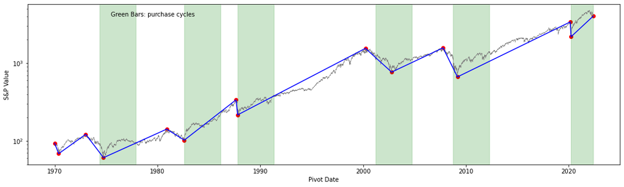

```python
df = get_zig_zag_pivots(raw_sp, drop_thresh)
fig, ax = plt.subplots(figsize=(18,5))

# add S&P Values
ax.plot(pd.to_datetime(df["Date"]), df.Close.values, color='grey', linewidth=0.5)
ax.scatter(df["Date"], df["Pivot_Price"], color = "red")

# add S&P500 Pivots
pivots = df.dropna(subset=["Pivot_Price"])
ax.plot(pd.to_datetime(pivots["Date"]), pivots["Pivot_Price"], color='blue')

# add purchase bars
purchase_periods = []
for lst in check_mark_purchase_plan(df,pivots,drop_thresh,savings_months, dca_months, 30):
    min_date = (lst["purchase_plan_date"].min())
    max_date = (lst["purchase_plan_date"].max())
    purchase_periods.append([min_date,max_date])

for cycle in purchase_periods:
    ax.fill_between(df["Date"], 0, 1,
                    where = df["Date"].apply(lambda x : cycle[0] <= x <= cycle[1]),
                    color='green', alpha=0.2, transform=ax.get_xaxis_transform())

# final graph formating
border = 0.2
y_rng = [(1 - border) * df.Close.values.min() , df.Close.values.max()*(1 + border) ]
ax.set_ylim(y_rng)
ax.set_xlabel("Pivot Date")
ax.set_ylabel("S&P Value")
ax.set_yscale('log')

ax.text(1990, 4000,"Green Bars: purchase cycles")

fig.savefig("log_snp.png")
```

#### Check Mark Strategy - Review

The pattern looks like a BtB with a trail afterwards. Although there's a chance that there's significant overfitting of the drop threshold, the relevant data set is too limited to do much more and 27% does seem to generalize from pre-90s to post-90s crashes. The 90s were the only time 27% failed, however, that was a unique situation that savy investors would have recognized. Therefore, I would conclude that 27% is actually a very important market indicator for the S&P500.

This implementation of the Check Mark strategy, apppears to have two major issues: prolonged bear markets and prolonged bull markets. Check Mark avoids a significant amount of the gains from the 90s bull market and also gets back in afterward, in the prolonged bear market of the early 2000s. After the real estate crash of 2009, the strategy also avoids all the gains from the bull market of the 2010s.

Of the two issues, avoiding the prolonged bull markets is the most damning. The 90s were a unique time and can be ignored as an outlier, but the post 2009 boom shows the that prolonged bull markets are a real thing, which may be caused by better economic policy(another source of endogeneity). As the graph is on a logarithmic scale, significant increases are actually exponential increases, and prolonged bull markets are where the market moves into another "order of magnitude". The logarithmic scale can be removed to view the full extent of the missed gains.

In a bid to avoid bear markets, which the 27% threshold seems to do well in identifying, we cut short the major bull runs, which causes the Check Mark strategy to lag behind DCA even worse than BtB.

# **CONCLUSION**

However, for the average reader who doesn't want to spend too much time learning about the financial markets, stick with Dollar Cost Averaging. No one has found a significantly better algorithm. Value Averaging is a promising alternative, but due to time constraints, this was not modeled. The link below demonstrates the Value Averaging algorithm, but doesn't test it over a very long time period.

The biggest piece of wisdom to add is "don't try to catch a falling knife". This is a saying from investors warning against picking the bottom. This is a knife catching/market timing strategy and this might be evidence that you should avoid trying to time the market.

# Further Investigation

Most investors believe that once the Fed raises rates, the party is over, which is why we see things like taper tandrum or the early 2022 drop. However, this is not easily modeled because sometimes the market ignores the Fed as in the 1990s and 2000s. With the small dataset of crashes available and the inherent unpredictability of future systemic issues, creating a FFR based algorithm is difficult and couldn't be done due to time constraints.

The benefit is that you can use the FFR as a proxy for expert opinion on the state of the economy and also when Wall Street is getting worried about their greed getting the best of them. This is a reasonable statement because the Fed is influenced by the major players on Wall Street so it's a way for the investor to use someone else's expertise to their advantage.

**Useful Links:**

- https://movement.capital/value-averaging-an-alternative-to-dollar-cost-averaging-or-lump-sum/
- https://fred.stlouisfed.org/series/FEDFUNDS

# **Bonus Material - To Drive Interest Only**

```python
# Helpful FFR code
def get_fed_funds_rates():
    save_file_name = "fedfunds.csv"

    if (not os.path.exists(save_file_name)):
        FRED_API_KEY = "get ur own" # you need your own key by registering with FRED
        param = {}
        param["api_key"] = FRED_API_KEY
        param["file_type"] = "json"

        FRED_URL = "https://api.stlouisfed.org/fred/series/observations"

        param["series_id"] = "FEDFUNDS"

        me.datetime.now().strftime("%Y-%m-%d")

        fred = requests.get(FRED_URL, params = param)
        jfred = json.loads(fred.text)

        dfred = pd.DataFrame(jfred["observations"])
        dfred = dfred.drop(["realtime_start","realtime_end"],axis=1).set_index("date")

        dfred.to_csv(save_file_name)

        return dfred
    else:
        temp_df = pd.read_csv(save_file_name)

        temp_df["date"] = pd.to_datetime(temp_df["date"])

        return temp_df.set_index("date")
```

# Further Investigation - Perfect Timing

- Sell All at Peak
- All-In at Trough
- Include Taxes
- Buy only during Bull markets

```python
def perfect_timing_strategy(threshold, tax = 0.2):

    pivots = get_zig_zag_pivots(df, threshold).dropna()

    def closure (df):
        peak_datez = pivots[pivots["Pivots"] == 1]["Date"].values
        trough_datez = pivots[pivots["Pivots"] == -1]["Date"].values
        df["purchase_price"] = (df["High"] + df["Low"] + 2 * df["Close"])/4

        savings_balance = 0
        shares_balance = 0


        if pivots.iloc[0]["Pivots"] == -1 :
            bear_market = False
        else:
            bear_market = True

        basis = 0
        for i, r in df.iterrows():
            if not bear_market:
                assert(savings_balance == 0)

            savings_balance = savings_balance + r["funding"]

            if r["Date"] in trough_datez:
                assert(shares_balance == 0)

                df.loc[i,"purchased_shares"] = savings_balance/r["purchase_price"]
                shares_balance = savings_balance/r["purchase_price"]

                basis = savings_balance

                savings_balance = 0
                df.loc[i,"savings_balance"] = savings_balance
                bear_market = False
            elif r["Date"] in peak_datez:

                gains = (r["purchase_price"] * shares_balance - basis)
                df.loc[i,"gains"] = gains

                if gains > 0 :
                    net_gains = gains * (1 - tax)
                    df.loc[i,"taxes"] = gains - net_gains
                    savings_balance = r["funding"] + net_gains + basis
                else:
                    savings_balance = r["funding"] + r["purchase_price"] * shares_balance

                df.loc[i,"savings_balance"] = savings_balance
                df.loc[i,"purchased_shares"] = -shares_balance
                basis = 0
                shares_balance = 0

                bear_market = True
            elif not bear_market:
                shares_balance = shares_balance + savings_balance/r["purchase_price"]
                df.loc[i,"purchased_shares"] = savings_balance/r["purchase_price"]
                basis = basis + savings_balance
                savings_balance = 0

            df.loc[i,"tax_basis"] = basis
            df.loc[i,"savings_balance"] = savings_balance

        df["total_shares"] = df["purchased_shares"].cumsum()
        df["total_shares"] = df["total_shares"].fillna(method="ffill")
        df["total_value"] = df["total_shares"] * df["Close"] +  df["savings_balance"]
        df["total_value"] = df["total_value"].apply(lambda x: round(x,2))
        df["pct_return"] = ((df["total_value"]/df["total_invested"]) - 1) * 100

        return df

    return closure
```

```python
sp_copy = raw_sp.copy()
funding = dca_funding(cpi = cpi_df)
perfect_strategy = perfect_timing_strategy(0.25)
tmp = backtester(sp_copy, funding, perfect_strategy)
tmp.iloc[-1,tmp.columns.get_loc("purchased_shares")] = 1 # keep last row to get current return
tmp = tmp.dropna(subset = ["purchased_shares"])
tmp = tmp[tmp["purchased_shares"] != 0 ]
tmp.iloc[-1,tmp.columns.get_loc("purchased_shares")] = 0

tmp.iloc[-1]
```

```
Calculating Pivots for  25.0 %
```

```
Date                2022-05-16 00:00:00
Open                         4013.02002
High                        4027.360107
Low                          3983.98999
Close                       4018.429932
Adj_Close                   4018.429932
Volume                       1121509000
latest                              NaN
funding                             0.0
total_invested                258073.66
purchase_price               4012.05249
purchased_shares                    0.0
savings_balance         12969088.194349
tax_basis                           0.0
gains                    6267530.826659
taxes                    1253506.165332
total_shares                        0.0
total_value                 12969088.19
pct_return                  4925.343613
Name: 13210, dtype: object
```